# assignment02

Jeff Nguyen 6524885309

28/08/2020

**University of Southern California**  
**Marshall School of Business**  
**FBE 506 Quantitative Method in Finance**

Assignment 02  
Student Name: Ngoc Son (Jeff) Nguyen  
Student ID: 6524885309

# **Question 1**

## a. Graph $Y = 1.5X + 4$

The function is a linear function so the graph is a straight line.

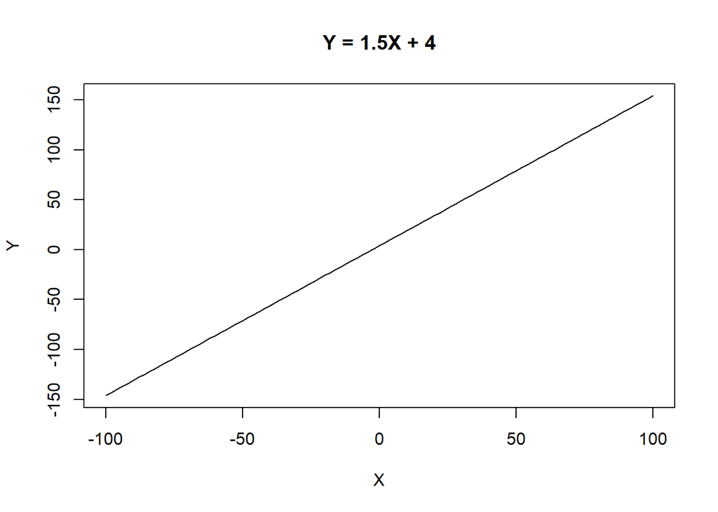

```r
# Graph $Y = 1.5X + 4$
curve(1.5*x + 4, from = -100, to = 100, ylab = "Y", xlab = "X", main = "Y = 1.5X + 4")
```

## b. Graph $Y = \ln{(X)}$

The function is an inverse function of an exponential function, the graph is a reflection of its related inverse function about the line Y = X. Y increases at a decelerated rate as X increases.

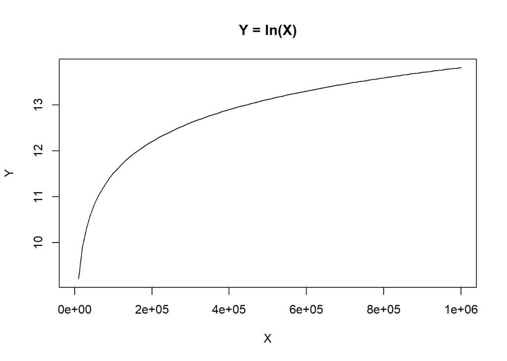

```r
# Graph $Y = \ln{(X)}$
curve(log(x), from = 0, to = 1000000, ylab = "Y", xlab = "X", main = "Y = ln(X)")
```

## c. Graph $Y = e^{X}$

The function is an exponential function, Y value increases at an accelerated rate as X increases.

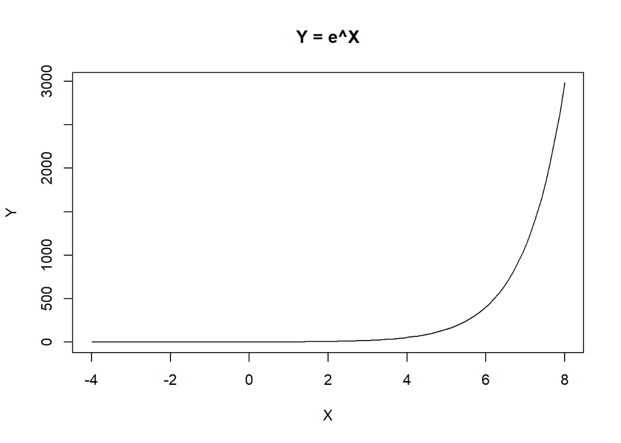

```r
# Graph $Y = e^{X}$
curve(exp(x), from = -4, to = 8, ylab = "Y", xlab = "X", main = "Y = e^X")
```

## d. Graph $Y = \frac{5}{X - 1}$

The function is rational function.

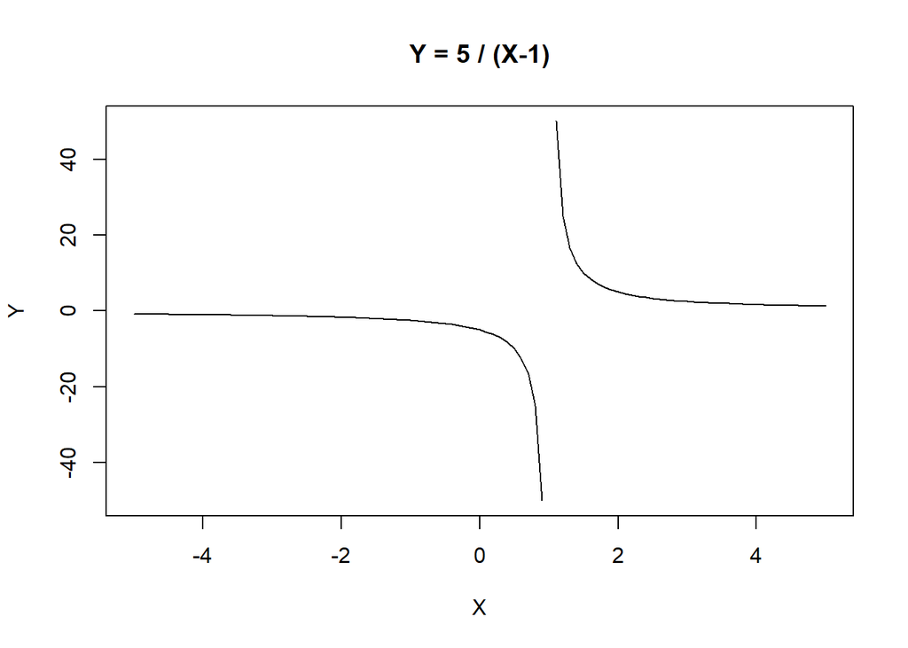

```r
# Graph $Y = \frac{5}{X - 1}$
curve(5/(x-1), from = -5, to = 5, ylab = "Y", xlab = "X", main = "Y = 5 / (X-1)")
```

## e. Graph $Y = X^2 - 2X + 20$

The function is a quadratic function–2nd degree polynomial–, the cure is a parabola,

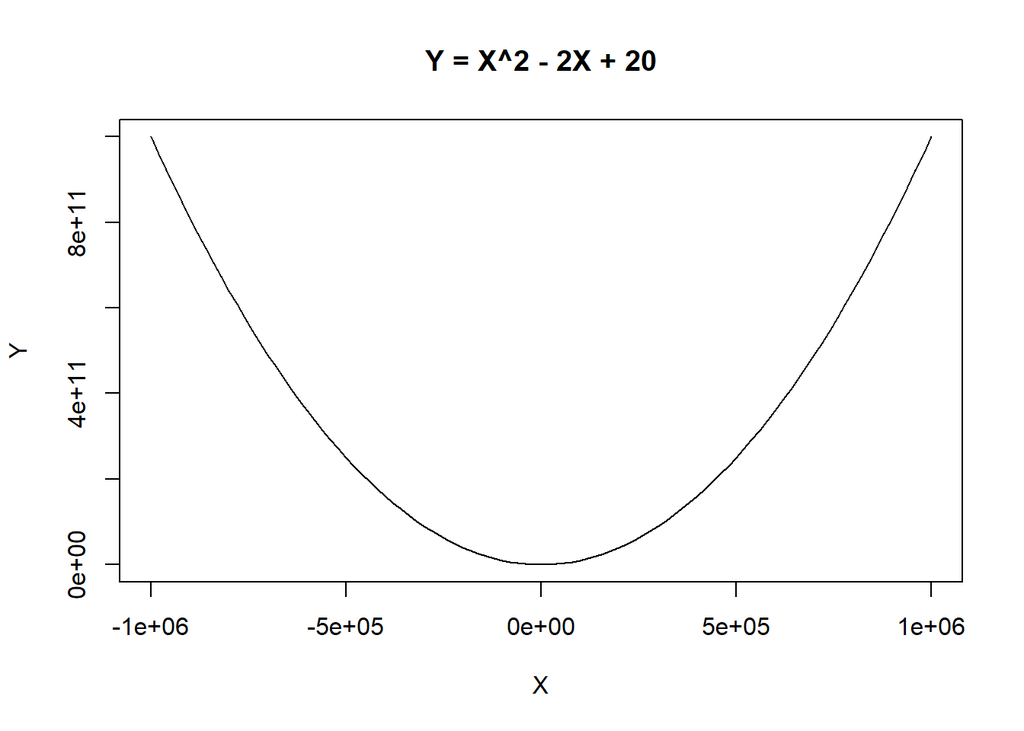

```r
# Graph $Y = X^2 - 2X + 20$
curve(x^2 - 2*x +20, from = -1000000, to = 1000000, ylab = "Y", xlab = "X", main = "Y = X^2 - 2X + 20")
```

## f. Graph $Y = X^3 - X^2 + 12X +20$

The function is a cubic function–3rd degree polynomial.

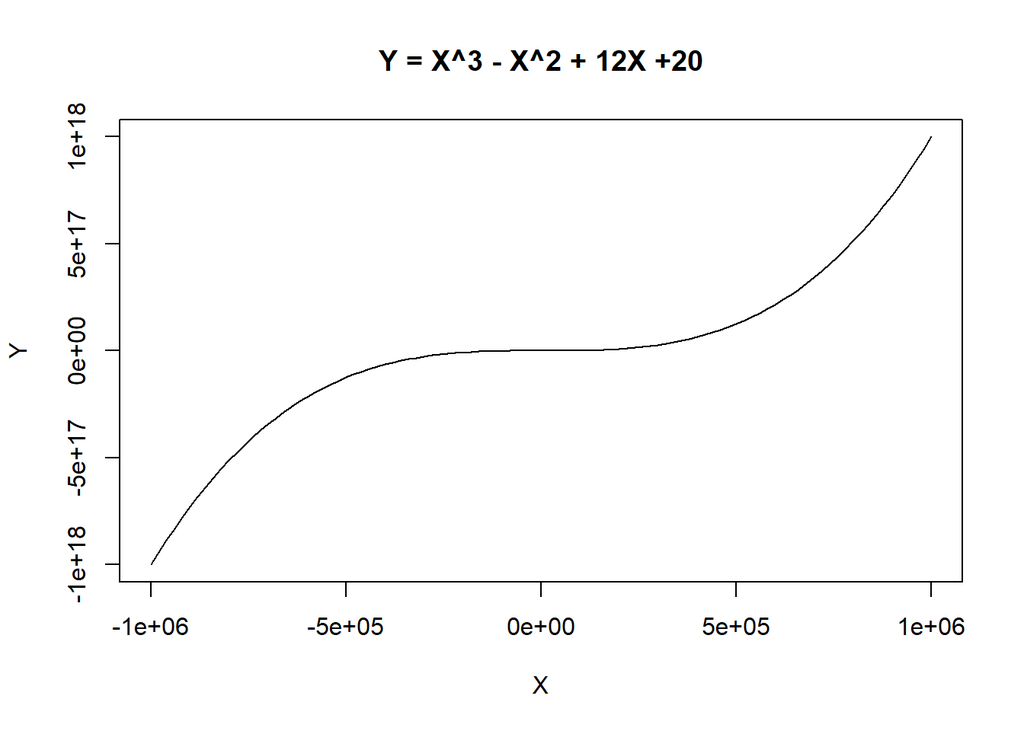

```r
# Graph $Y = X^3 - X^2 + 12X +20$
curve(x^3  - x^2 + 12*x + 20, from = -1000000, to = 1000000, ylab = "Y", xlab = "X", main = "Y = X^3 - X^2 + 12X +20")
```

# **Question 2**

## a. Graph $Y = .5^{T}$

The function is an exponential function. The function is strictly decreasing as the base is less than 1.

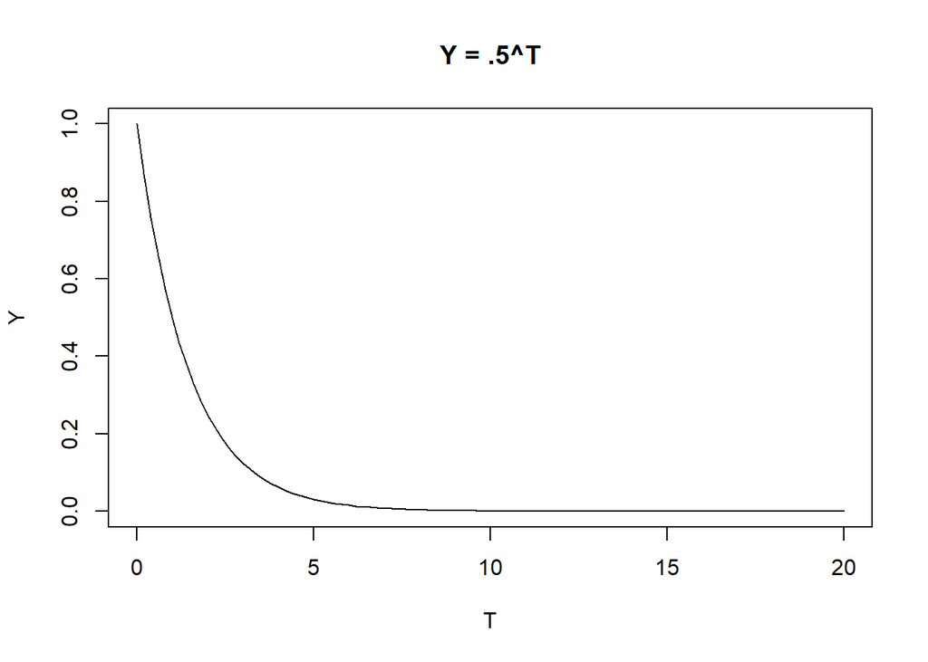

```r
# Graph $Y = .5^{T}
curve(.5^x, from = 0, to = 20, ylab = "Y", xlab = "T", main = "Y = .5^T")
```

## b. Graph $Y = 2^{T}$

The function is an exponential function, the function is stricly increasing as the base is greater than 1.

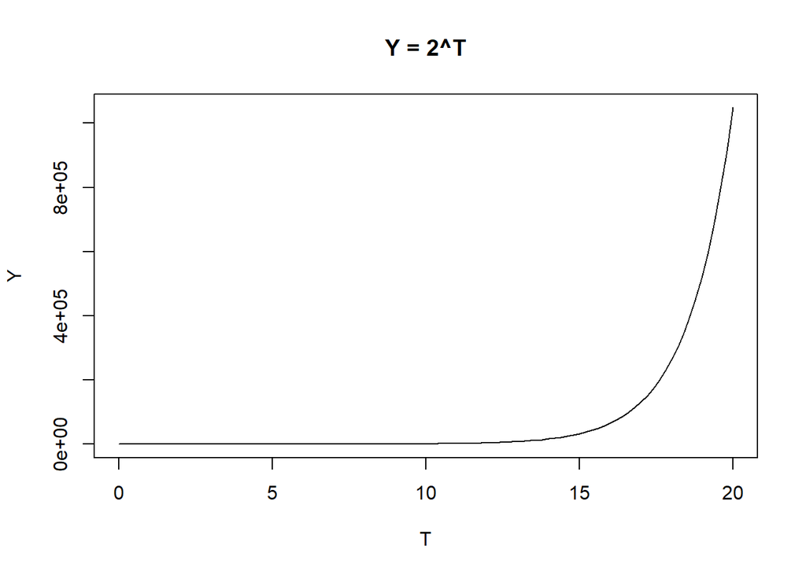

```r
# Graph $Y = 2^{T}
curve(2^x, from = 0, to = 20, ylab = "Y", xlab = "T", main = "Y = 2^T")
```

## c. Graph $Y = (-.5)^{T}$

The function is an oscillating function.

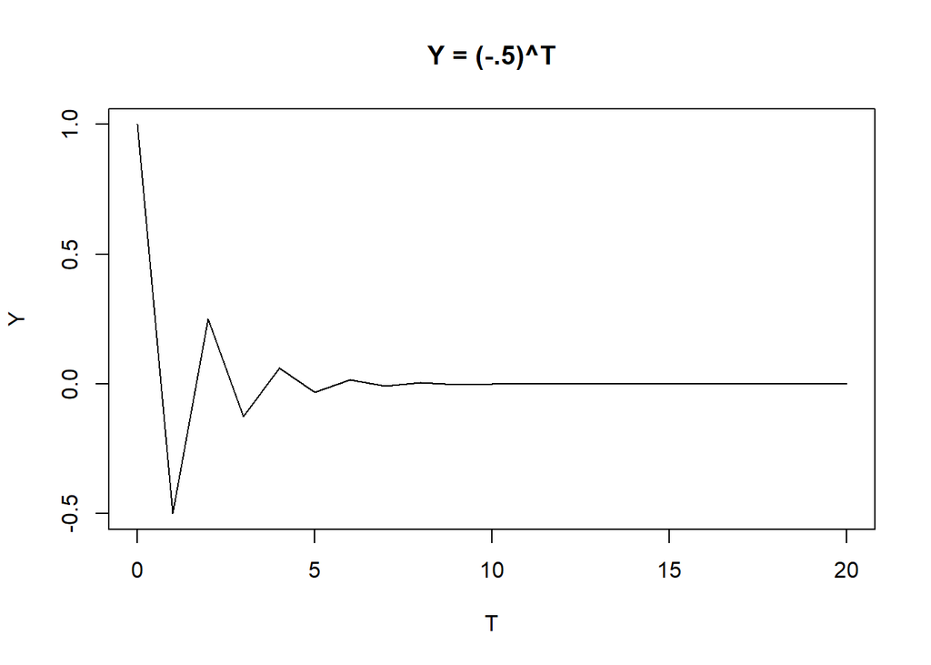

```r
x = c(0:20)
# Graph $Y = (-.5)^{T}
plot(x, (-.5)^(x), type = "l", main = "Y = (-.5)^T", xlab = "T", ylab = "Y")
```

# **Question 3**

Install the packages and call the library “quantmod” and download data for S&P 500 (GSPC), Apple (AAPL) from Yahoo and Real Gross Domestic Product (GDPC1) from FRED.

```r
# Install the packages and call the library "quantmod"
#install.packages("quantmod") # uncomment to install as neccessary
library(quantmod)
# Get data for S&P500, AAPL
gspc <- getSymbols("^GSPC", src = "yahoo") # S&P500
```

[output not shown]

```r
aapl <- getSymbols("AAPL", src = "yahoo") # AAPL
real_gdpc1 <- getSymbols("GDPC1", src = "FRED") # Real GDP
```

Convert S&P 500 index from daily to monthly and generate returns data.

```r
# Convert S&P 500 from daily to monthly
monthly_gspc <- to.monthly(GSPC)

# Convert index to returns
returns_monthly_gspc <- diff(log(GSPC))
```

Graphing monthly S&P 500 index

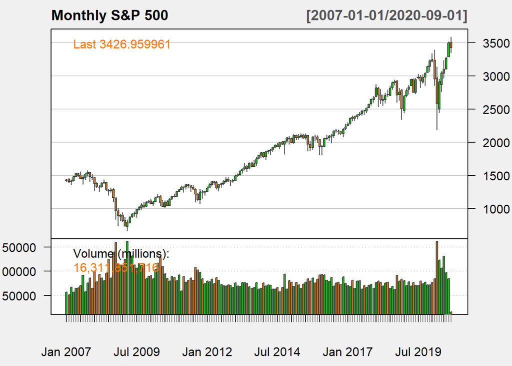

```r
# Graphing monthly S&P 500 index
chartSeries(monthly_gspc, name = "Monthly S&P 500", type = "candlesticks", theme = chartTheme("white"))
```

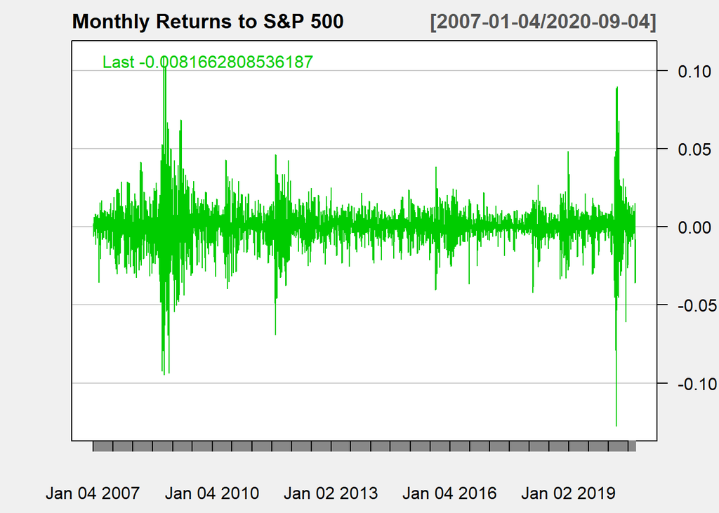

```r
# Graphing monthly S&P 500 returns
chartSeries(returns_monthly_gspc$GSPC.Adjusted, name = "Monthly Returns to S&P 500", type = "candlesticks", theme = chartTheme("white"))
```

# **Question 4**

Graphing real quarterly GDP

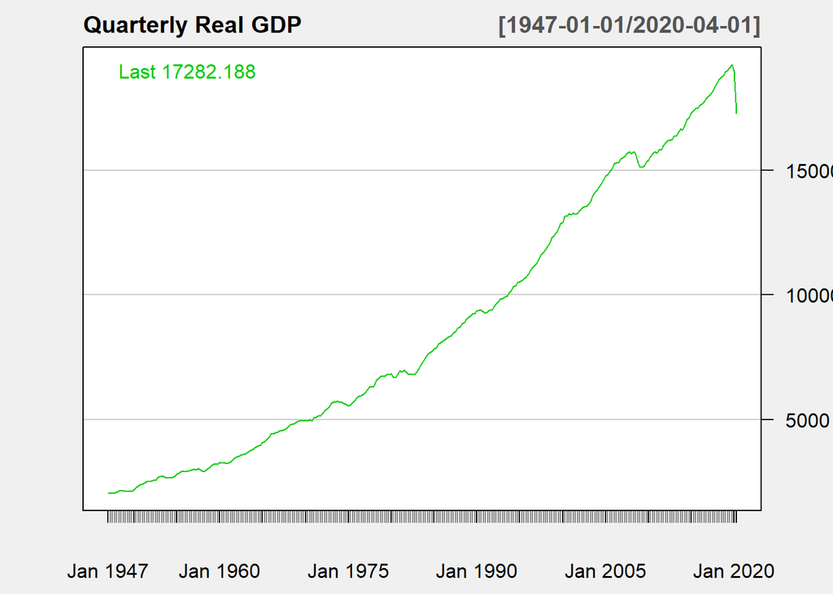

```r
# Graphing real quarterly GDP
chartSeries(GDPC1, name = "Quarterly Real GDP", type = "line", theme = chartTheme("white"))
```

Convert real GDP to real GDP growth and graph

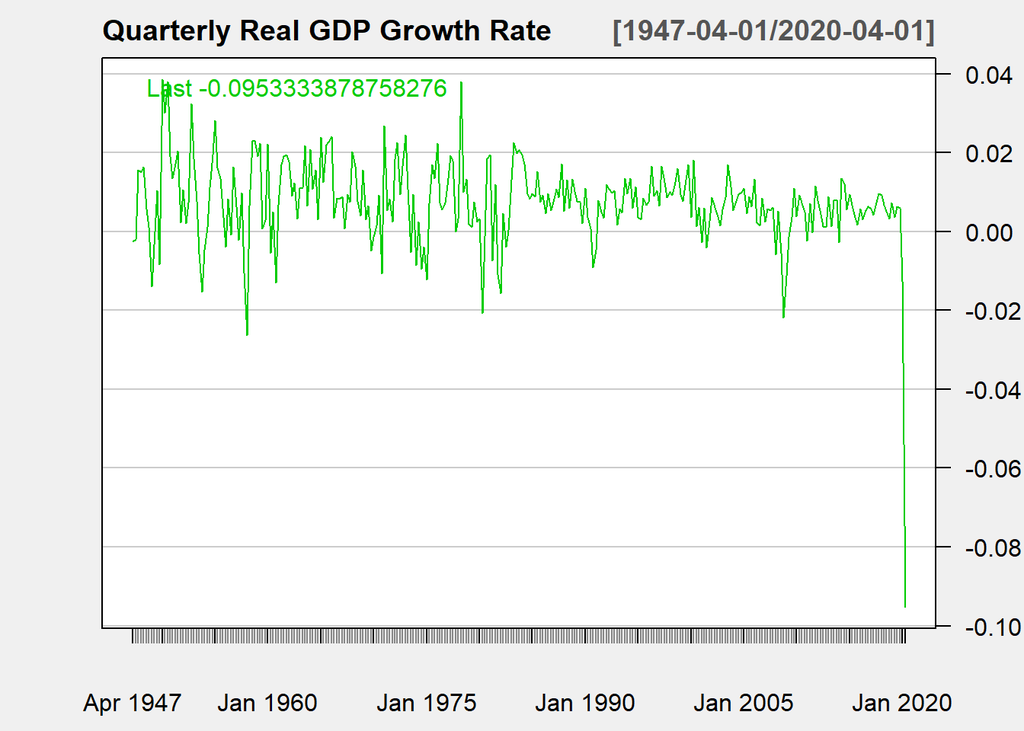

```r
# Convert index to growth
growth_gdpc1 <- diff(log(GDPC1))

# Graph real GDP growth
chartSeries(growth_gdpc1, name = "Quarterly Real GDP Growth Rate", type = "line", theme = chartTheme("white"))
```

# **Question 5**

Convert AAPL from daily to monthly and generate returns data.

```r
# Convert S&P 500 from daily to monthly
monthly_aapl <- to.monthly(AAPL)

# Convert index to returns
returns_monthly_aapl <- diff(log(AAPL))
```

Graphing monthly AAPL price

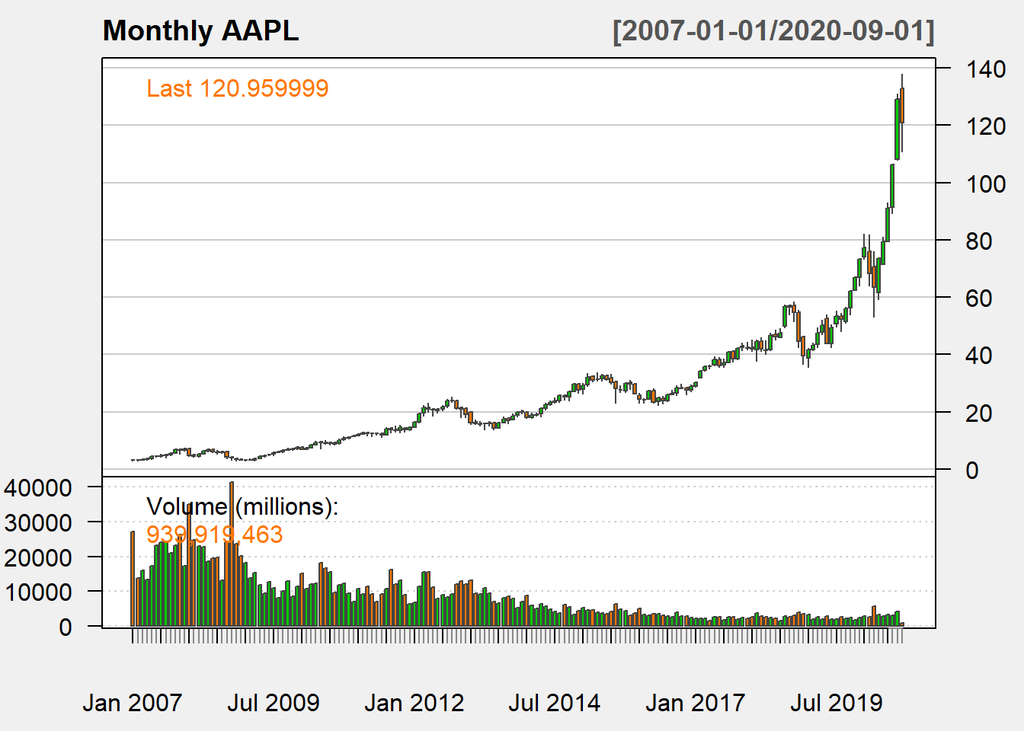

```r
# Graphing monthly AAPL price
chartSeries(monthly_aapl, name = "Monthly AAPL", type = "candlesticks", theme = chartTheme("white"))
```

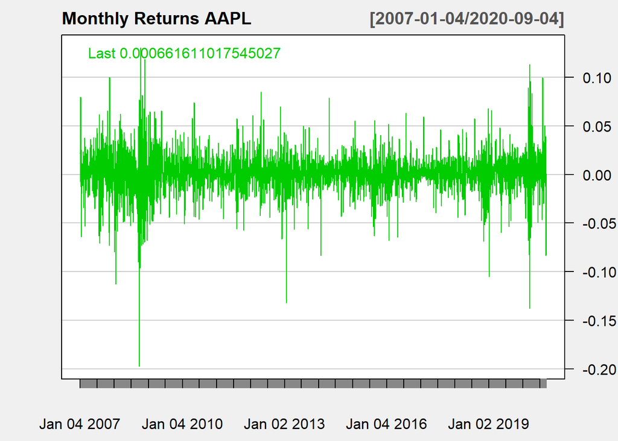

```r
# Graphing monthly AAPL returns
chartSeries(returns_monthly_aapl$AAPL.Adjusted, name = "Monthly Returns AAPL", type = "candlesticks", theme = chartTheme("white"))
```

# **Question 6**

Graph monthly AAPL and monthly S&P500 on one coordinate system:

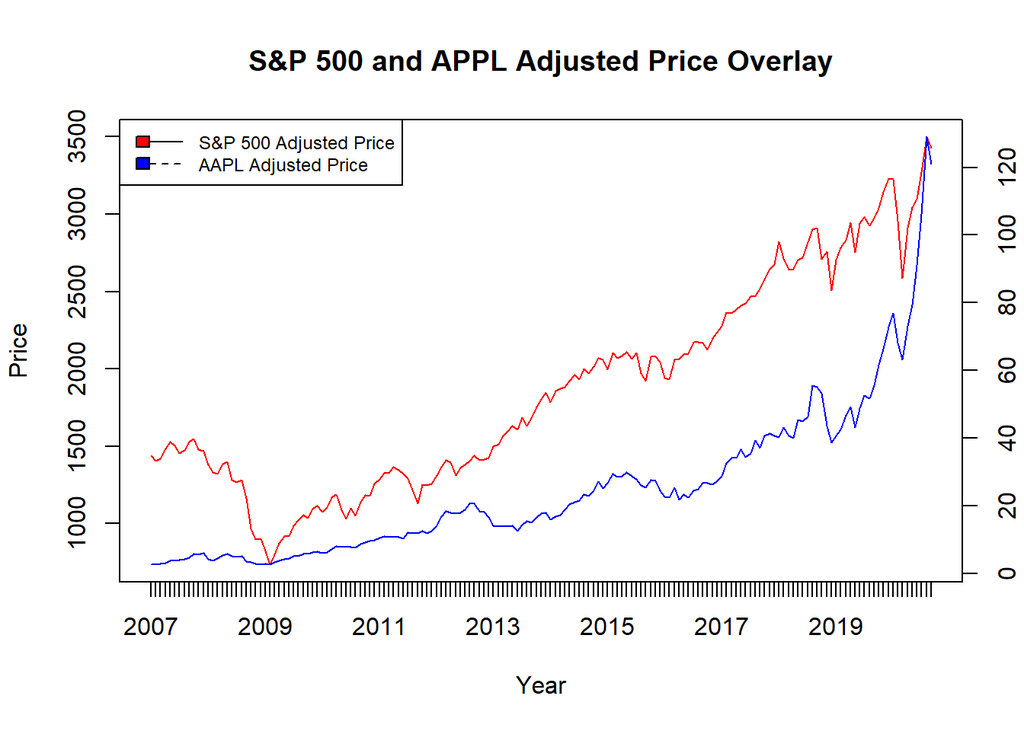

```r
# Initialize xts objects contain adjusted price for S&P 500 and AAPL and merge
gspc_xts <- as.xts(monthly_gspc[,"GSPC.Adjusted"])
aapl_xts <- as.xts(monthly_aapl[,"AAPL.Adjusted"])
price_compare <- merge.xts(gspc_xts, aapl_xts)

# Graph monthly AAPL and monthly S&P500 on one coordinate system
# Plot S&P 500
plot(as.zoo(price_compare[, "GSPC.Adjusted"]), screens = 1, main = "S&P 500 and APPL Adjusted Price Overlay",
     xlab = "Year", ylab = "Price", col = "Red")

# Keep working on the same plot
par(new = TRUE)

# Plot AAPL and suppress axis value
plot(as.zoo(price_compare[, "AAPL.Adjusted"]), screens = 1, xaxt = "n", yaxt = "n", xlab = "", ylab = "", col = "Blue")

# Add right-handed axis to display AAPL price
axis(4)

# Add legend
legend("topleft", c("S&P 500 Adjusted Price", "AAPL Adjusted Price"), lty = 1:3, cex = 0.75, fill = c("red", "blue"))
```

Observations from the overlay chart above regarding S&P 500 and AAPL: 1. Seasonal Trend: Both display similar seasonal trend with up and down spikes in price. 2. Cyclical Trend: Both is affected by business cycle, S&P 500 more so than AAPL (most noticably during the Great Recession of ’07 where S&P 500 experienced sharp downturn compare to AAPL)  
3. Auto-correlation: Both behave similar in this regard where both rises for some times when they rise and vice versa. 4. Randomness: Price of both is unpredictable. 5. Time: Both follows similar time trend.

# **Question 7**

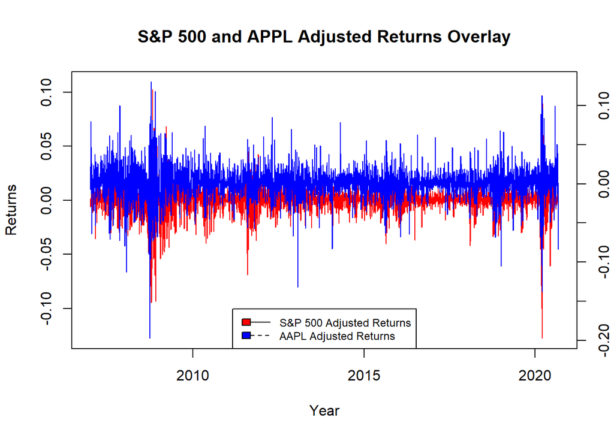

```r
# Initialize xts objects contain close price returns for S&P 500 and AAPL and merge
returns_gspc_xts <- as.xts(returns_monthly_gspc[,"GSPC.Adjusted"])
returns_aapl_xts <- as.xts(returns_monthly_aapl[,"AAPL.Adjusted"])
returns_compare <- merge.xts(returns_gspc_xts, returns_aapl_xts)

# Graph monthly AAPL and monthly S&P 500 returns on one coordinate system
# Plot S&P 500 monthly returns
plot(as.zoo(returns_compare[, "GSPC.Adjusted"]), screens = 1, main = "S&P 500 and APPL Adjusted Returns Overlay",
     xlab = "Year", ylab = "Returns", col = "Red")

# Keep working on the same plot
par(new = TRUE)

# Plot AAPL monthly returnsand suppress axis value
plot(as.zoo(returns_compare[, "AAPL.Adjusted"]), screens = 1, xaxt = "n", yaxt = "n",
     xlab = "", ylab = "", col = "Blue")

# Add right-handed axis to display AAPL price
axis(4)

# Add legend
legend("bottom", c("S&P 500 Adjusted Returns", "AAPL Adjusted Returns"), lty = 1:3, cex = 0.75, fill = c("red", "blue"))
```

In addition to the trends as commented above, AAPL and S&P 500 returns do not always trend in the same direction. This could be attributed to fluctuations in stock price experienced by single companies based on there quarterly earnings season performance, whereas the indices such as the S&P 500 is more or less insulated from these fluctations.